# Some Notes on Isotopes

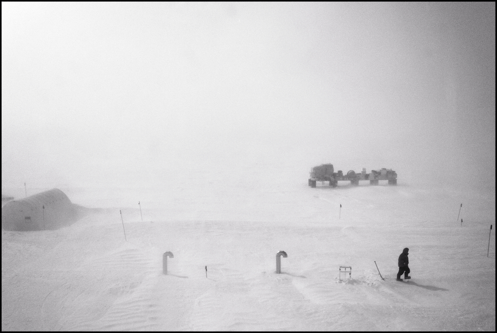

```python
Image("../figs/P1020067_gimp.jpg")
```

# Nucleotides - Atomic Structure

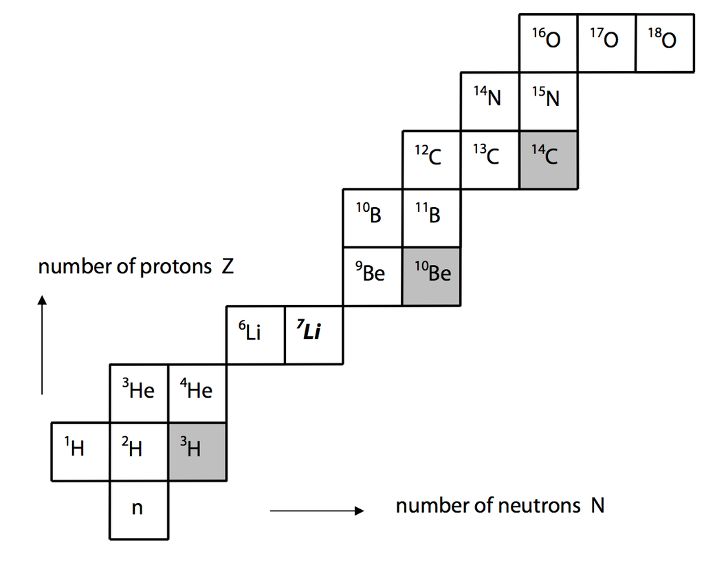

```python
Image("../figs/nucleotides.png", width = 400)
```

### Atoms nuclei consist of two kinds of particles; protons and neutrons - they roughly have the same mass. Protons are positively charged.

- Atomic Number Z: number of protons
- N: The number of neutrons
- The mass number A is the sum of protons and neutrons (nucleons) and $A = Z+A$

### Elements with the same $Z$ but different $A$ are called **isotopes**.

### The Atomic number $Z$ typically determines the chemical properties of an element.

- For the *light elements* the most abundant nuclides lie on the $Z = N$ line and are stable $\left(^{2}_{1}\text{H}_2\,,\, ^{4}_{2}\text{He}_2\,,\, ^{12}_{\,\,6}\text{C}_6 \,,\, ^{14}_{\,\,7}\text{N}_7 \,,\, ^{16}_{\,\,8}\text{O}_8\right)$.
- A slight deviation from the $Z = N$ line is also possible for stable nuclei $\left(^{17}_{\,\,8}\text{O}_9 \,,\,^{18}_{\,\,8}\text{O}_{10}\right)$.
- Assymetric nuclei typically have lower natural abundances.
- Oxygen Triplet: $^{16}\text{O}\,,\,^{17}\text{O}\,,\,^{18}\text{O}:\,0.9976\,,\,0.00038\,,\,0.00205$
- Hydrogen : $^{1}\text{H}\,,\,^{2}\text{H}:\,0.99985, \,0.00015$

# Abundance and Fractionation

## Isotopic Abundance

Isotopic Abundances are defined as: $R = \frac{\text{abundance of rare isotope}}{\text{abundance of abundant isotope}}$

so we can define $^{18}\text{R(H}_2\text{O}) = \frac{\left[\text{H}_2{}^{18}\text{O}\right]}{\left[\text{H}_2{}^{16}\text{O}\right]}$, $^{2}\text{R(H}_2\text{O}) = \frac{\left[\text{HD}{}^{16}\text{O}\right]}{2\left[\text{H}_2{}^{16}\text{O}\right]}$

This is **not** an isotope concentration (molar ratio). This would be defined as: $\frac{\left[\text{H}_2{}^{18}\text{O}\right]}{\left[\text{H}_2{}^{18}\text{O}\right]+ \left[\text{H}_2{}^{16}\text{O}\right]}$

Another (not so) common expression that can be find in the literature is the atom%. This is defined as: $\frac{N_X}{N_{tot}}\cdot100\%$, where $N_X$ the number of atoms of the isotope X and $N_{tot}$ the total number of atoms.

## Exercise 1

[figure not shown]

```python
Image("../figs/Deuterium_oxide_Norsk.jpg", width = 500)
```

In the picture above you can see an ampoule of heavy water made by Norsk Hydro in Norway during the 2nd World War. This heavy water was planned to be used as neutron modetrator for the German Nuclear Weapon Project an action that was prevended by [sabotages carried out by the Norwegian resistance and the allies](https://en.wikipedia.org/wiki/Norwegian_heavy_water_sabotage).

Using the information on the label of the ampoule express the deuterium content of this heavy water in atom% as well as ${}^2\text{R(H}_2\text{O)}$.

# Fractionation

The various *[isotopologues](https://goldbook.iupac.org/I03351.html)* of water present very small differences with respect to their chemical and mostly physical properties. This is a phenomenon called *isotopic fractionation*. Typical examples of processes where isotopic fractionation can be observed are the transitions between states (liquid to vapor, solid to liquid etc.).

## Reasons for isotopic fractionation

- **Kinetics** Temperature determines the kinetic energy of a molecule as $kT \sim \frac{1}{2}mv^2$. As a result, at the same $T$ the heavier isotopologues will present lower velocities on average. As a result diffusion velocities and collision frequencies will be lower for the heavier isotopologues.
- **Binding Energies** Heavier isotopologues generally (not always!) present higher binding energies thus "sitting" deeper in the energy well as seen in the picture below.

### **Practically this results in:**

- Light isotopologues react faster in chemical reactions.
- Light isotopologues tend to have higher vapor pressures and thus evaporate easier.
- At high temperatures fractionation effects diminish.

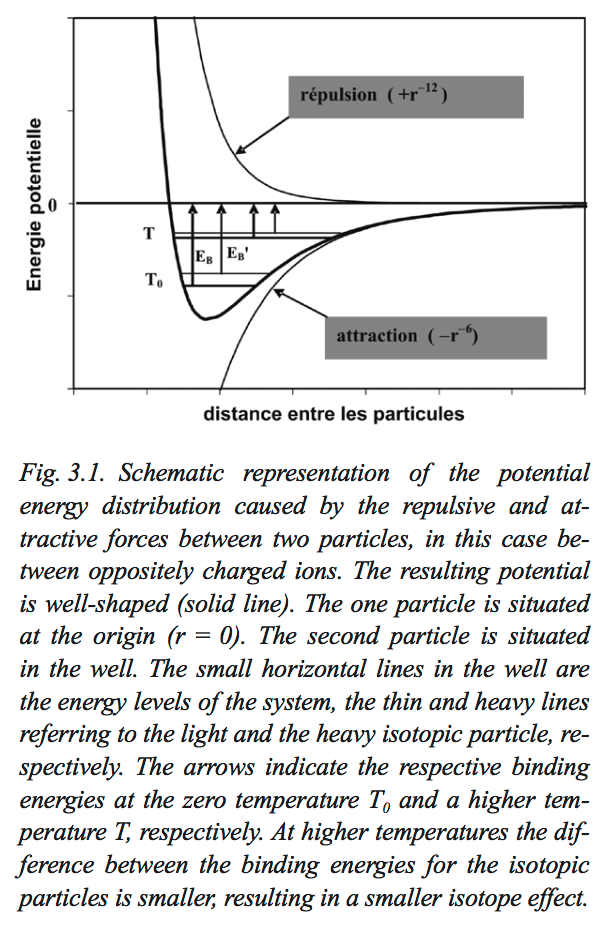

```python
Image("../figs/binding_energies_mook.png", width = 500)
```

# Fractionation Factors - Equilibrium, Diffusion, Kinetic

## Equilibrium Fractionation

Lets assume the following reaction where ${}^{0}\text{X}$ and ${}^{1}\text{X}$ are two different isotopes of the element X.

$\text{A}{}^{0}\text{X} + \text{B}{}^{1}\text{X} \rightleftharpoons \text{A}{}^{1}\text{X} + \text{B}{}^{0}\text{X}$

then the equilibrium constant is $K_X(T) = \frac{\left[\text{A}{}^{1}\text{X}\right]\left[ \text{B}{}^{0}\text{X} \right] }{\left[ \text{A}{}^{0}\text{X} \right] \left[ \text{B}{}^{1} \text{X} \right]} = \frac{R_{AX}}{R_{BX}} = \alpha_{AX/BX}$

Here $\alpha_{AX/BX} $ is called the **fractionation factor**.

A very relevant reaction for ice core studies is the under equilibrium evaporation/condensation process of the water molecule:

$ \text{H}_2{}^{16}\text{O}_{vap} + \text{H}_2{}^{18}\text{O}_{liq} \leftrightharpoons \text{H}_2{}^{16}\text{O}_{liq} + \text{H}_2{}^{18}\text{O}_{vap} $

For which the fractionation factor of the ${}^{18}\text{O}$ will be: $K(T) = \frac{\left[\text{H}_2{}^{18}\text{O}_{vap}\right]\left[ \text{H}_2{}^{16}\text{O}_{liq} \right] }{\left[ \text{H}_2{}^{16}\text{O}_{vap} \right] \left[ \text{H}_2{}^{18} \text{O}_{liq} \right]} = \frac{{}^{18}R_{vap}}{{}^{18}R_{liq}} = {}^{18}\alpha_{v/l}$

${}^{18}\alpha_{v/l}$ has a value vey close to 1 (remember that especially at higher temperatures the fractionation effects are of very small magnitude). For convenience we also define the *fractionation* ${}^{18}\varepsilon_{v/l} = {}^{18}\alpha_{v/l} - 1$ that has a value very close to zero and it is typically expressed in per mil $\text{\permil}$

It becomes clear that negative values of $\varepsilon$ designate *depletion* in the rare isotope and positive values of $\varepsilon$ designate *enrichment*

## Exercise 2

Show that ${}^{18}\alpha_{v/l} = {{}^{18}\alpha_{l/v}}^{-1}$

## Exercise 3

The fractionation factor ${}^{18}\alpha_{v/l}$ is given by: $\ln {}^{18}\alpha_{l/v} = \frac{-1137}{T^2} + \frac{0.4156}{T^{}} + 0.0020667 $ (T in Kelvin)(Majoube 1971)

Calculate ${}^{18}\alpha_{l/v}$ and ${}^{18}\varepsilon_{l/v}$ for $T = 0, 10, 15 \,\,{}^{o}\text{C}$

Calculate ${}^{18}\alpha_{v/l}$ and ${}^{18}\varepsilon_{v/l}$ for the same temperatures.

Show that ${}^{18}\varepsilon_{v/l} \approx -{}^{18}\varepsilon_{l/v}$

## Exercise 4

[SLAP2](https://nucleus.iaea.org/rpst/referenceproducts/referencematerials/Stable_Isotopes/2H18O-water-samples/SLAP2.htm) is an international reference material distributed by the [IAEA](https://nucleus.iaea.org/rpst/index.htm) and is used in the definition of the VSMOW-SLAP scale. It is very depleted with respect to ${}^{18}\text{O}$ and D and originates from Antarctic snow. Its isotopic composition is ${}^{18}\text{R}_{slap} = 1893.91 \text{ppm}$. Assume a liquid/vapor equilibrium system at the temperatures of Exercise 3 and calculate the isotopic composition of the vapor and liquid $\left({}^{18}\text{R}_{slap-l},\,\,{}^{18}\text{R}_{slap-v}\right)$

# Kinetic Fractionation

- Kinetic effects occur when complete removal of the formed compount takes place.
- Kinetic fractionation factors are defined exactly as $\alpha_{kin} = \frac{R_{new}}{R_{old}}$ ($\alpha_{kin}>1$ for enrichment and vice versa for depletion).
- Kinetic effects are relatively stronger (WHY?)

# Transport Fractionation

These effects are due to the different diffusivities (mobilities) of the **molecules**.

## Exercise 5

If the diffusion coefficient of a gas A transported in gas B is $D_{A-B}\propto T^{3/2} \left(1/M_1 + 1/M_2 \right) ^{1/2}$ calculate $D_{\text{HD}{}^{16}\text{O}}/D_{\text{H}_2{}^{16}\text{O}}$, $D_{\text{H}_2{}^{18}\text{O}}/D_{\text{H}_2{}^{16}\text{O}}$

Calculate the equivalent fractionation factors for the three following cases:

- $\alpha_{dif} = \frac{D_i}{D_j}$
- $\alpha_{dif} = {\left(\frac{D_i}{D_j}\right)}^{1/2}$
- $\alpha_{dif} = {\left(\frac{D_i}{D_j}\right)}^{3/2}$

### Measurements of the diffusivity ratios give:

$D_2 = D_{air}\cdot0.9755 \,\,\text{and}\,\,D_{18} = D_{air}\cdot 0.9723$ and

$D_{air} = 0.211\cdot10^{-4}\left(T/T_0\right)^{1.94}\left(p_0/p \right)\,\,\left[\text{m}^2\text{sec}^{-1}\right]$

## Exercise 6

Calculate $D_2$ and $D_{18}$ as a function of temperature for $p = 1 \,\,\text{Atm}$

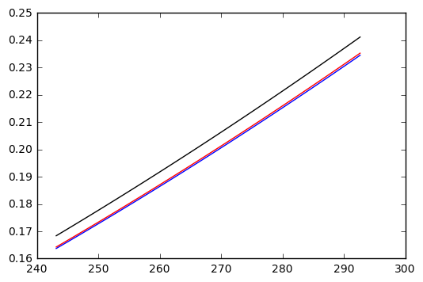

```python
from vaspy import diffusivity
temps = np.arange(-30, 20, 0.5) + 273.15
dif_inst = diffusivity.AirDiffusivity(temps)
d_air = dif_inst.Da*1e4 #cm2sec-1
d_2 = dif_inst.deuterium()*1e4 #cm2sec-1
d_18 = dif_inst.o18()*1e4 #cm2sec-1
plt.plot(temps, d_air, "k")
plt.plot(temps, d_18, "b")
plt.plot(temps, d_2, "r")
plt.show()
```

# The $\delta$ notation

Generally isotopic abundances are reported using the $\delta$ notation. $\delta^{18}\text{O} = \left(\frac{{}^{18}\text{R}_{sample}}{{}^{18}\text{R}_{std}} - 1\right) \times 1000 \text{ permile}$

Std here refers to a standard water. [VSMOW](https://en.wikipedia.org/wiki/Vienna_Standard_Mean_Ocean_Water) is considered as the international reference and all isotopic compositions are reported with respect to it.

## Exercise 6

The isotopic composition of the VSMOW water is ${}^{18}\text{O}/{}^{16}\text{O} = 2005.2$ ppm. Calculate $\delta^{18}\text{O}_{VSMOW}$.

# The Rayleigh Fractionation Model

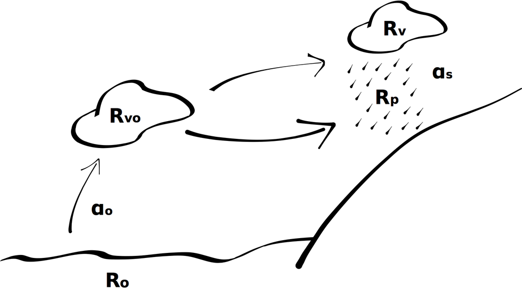

```python
Image("../figs/rayleigh_scheme.png", width = 600)
```